# Procrastination and Health

Author

Cormac Monaghan

Published

February 2, 2024

# Introduction

This document performs multiple binary logistic regression analyses to assess how well several health related problems and health protective behaviors (DVs) are explained by procrastination (IV). This analysis uses data from the 2020 wave of the [Health and Retirement Study (HRS)](https://hrs.isr.umich.edu/).

```r
path_data <- "./01__Data/02__Processed/"
path_graphics <- "./02__Models/Results/Figures/02__GLM_Plots/"

# Reading in data
health_data <- readxl::read_xlsx(here::here(path_data, "Health_HRS.xlsx"))
```

# HRS Dataset

The HRS, administered by the Institute for Social Research at the University of Michigan, is a longitudinal panel study that predominantly focuses on adults over the age of 50. The study collects, biennially, detailed information pertaining to respondent’s physical, cognitive, financial, employment, family, and psychosocial conditions. Similarly, in each wave, experimental modules are administered at the end of the core interview. These modules consist of concise questionnaires designed to explore new topics or supplement existing core survey data. However, each respondent only receives one experimental module, and the sample sizes for each module constitute approximately 10% of the core sample.

## Health Problems and Health Protection

Within the HRS dataset, we have a data on 9 different health problems and 6 different health protective behaviors. These have been coded as either $0$ (not present/not done) or $1$ (present/done).

```r
health_data %>%
  select(
    ID, Age, Gender, Education, College, Back_pain:Alcohol, Smoker_current,
    Blood_pressure:Dental_visit_2_years, Total_depression) %>%
  rename(Drinking = "Alcohol", Smoker = "Smoker_current") %>%
  head(n = 4) %>%
  kableExtra::kbl(align = 'c') %>%
  kableExtra::kable_styling(
    full_width = FALSE,
    bootstrap_options = c("striped", "hover", "condensed", "responsive"))
```

| ID | Age | Gender | Education | College | Back_pain | Headache | Fatigue | Drinking | Smoker | Blood_pressure | Diabetes | Cholesterol | Heart_condition | Prostate_exam | Mammogram | Cholesterol_screening | Pap_smear | Flu_shot | Dental_visit_2_years | Total_depression |
| --- | --- | --- | --- | --- | --- | --- | --- | --- | --- | --- | --- | --- | --- | --- | --- | --- | --- | --- | --- | --- |
| 1 | 76 | 1 | 4 | 1 | 0 | 0 | 0 | 1 | NA | 0 | 1 | 1 | 0 | NA | 1 | 1 | 0 | 1 | 1 | 0 |
| 2 | 80 | 1 | 5 | 1 | 1 | 0 | 0 | 0 | NA | 0 | 0 | 0 | 0 | NA | 1 | 1 | 0 | 1 | 1 | 3 |
| 3 | 89 | 0 | 4 | 1 | 0 | 0 | 0 | 0 | NA | 1 | 0 | 0 | 0 | 1 | NA | 1 | NA | 1 | 1 | 2 |
| 4 | 88 | 1 | 0 | 0 | 0 | 0 | 0 | 0 | 0 | 1 | 1 | 0 | 0 | NA | 0 | 1 | 0 | 1 | 0 | 1 |

## Procrastination

During the 2020 wave of data collection, one of these experimental modules included a module termed “long-term care insurance procrastination”. This module was split into two parts with the second half incorporating a procrastination measure with the aim of investigating how procrastination influences decision-making in later life.

```r
health_data %>%
  select(ID, Procras_1:Procras_12, Total_procrastination) %>%
  head(n = 4) %>%
  kableExtra::kbl(align = 'c') %>%
  kableExtra::kable_styling(
    full_width = FALSE,
    bootstrap_options = c("striped", "hover", "condensed", "responsive"))
```

| ID | Procras_1 | Procras_2 | Procras_3 | Procras_4 | Procras_5 | Procras_6 | Procras_7 | Procras_8 | Procras_9 | Procras_10 | Procras_11 | Procras_12 | Total_procrastination |
| --- | --- | --- | --- | --- | --- | --- | --- | --- | --- | --- | --- | --- | --- |
| 1 | 2 | 2 | 2 | 2 | 2 | 2 | 2 | 2 | 2 | 1 | 1 | 2 | 22 |
| 2 | 3 | 3 | 4 | 4 | 4 | 4 | 3 | 3 | 4 | 4 | 3 | 2 | 41 |
| 3 | NA | NA | NA | NA | NA | 3 | 2 | NA | NA | NA | NA | NA | 5 |
| 4 | 5 | 5 | 5 | 5 | 5 | 5 | 5 | 5 | 5 | 5 | 5 | 5 | 60 |

# Preliminary Analysis

## Descriptive Statistics

The descriptive statistics for each of our continuous study variables (procrastination, depression, and age) are computed and outlined below:

```r
health_data %>%
  filter(complete.cases(Total_procrastination)) %>%
  select(Age, Total_procrastination, Total_depression) %>%
  rename(Procrastination = "Total_procrastination", Depression = "Total_depression") %>%
  tidyr::gather(key = "Variable", value = "Value") %>%
  group_by(Variable) %>%
  summarise(
    Mean = round(mean(Value, na.rm = TRUE), digits = 2),
    `95\ % CI` = paste0(round(t.test(Value, conf.level = 0.95)$conf.int[1], digits = 2), " - ", round(t.test(Value, conf.level = 0.95)$conf.int[2], digits = 2)),
    `Std. Error Mean` = round(plotrix::std.error(Value, na.rm = TRUE), digits = 2),
    Median = median(Value, na.rm = TRUE),
    SD = round(sd(Value, na.rm = TRUE), digits = 2),
    Range = paste0(range(Value, na.rm = TRUE)[1], " - ", range(Value, na.rm = TRUE)[2])
    ) %>%
  kableExtra::kbl(caption = "Descriptive Statistics", align = 'c', ) %>%
  kableExtra::kable_styling(
    full_width = FALSE,
    bootstrap_options = c("striped", "hover", "condensed", "responsive"))
```

Descriptive Statistics

| Variable | Mean | 95 % CI | Std. Error Mean | Median | SD | Range |
| --- | --- | --- | --- | --- | --- | --- |
| Age | 67.83 | 67.27 - 68.38 | 0.28 | 66 | 10.46 | 30 - 95 |
| Depression | 1.59 | 1.48 - 1.7 | 0.06 | 1 | 2.11 | 0 - 8 |
| Procrastination | 28.35 | 27.73 - 28.97 | 0.32 | 27 | 11.63 | 1 - 60 |

## Frequency Analysis

Additionally frequency analysis for our categorical variables our outline below:

**Education**

```r
frequency <- health_data %>%
  filter(complete.cases(Education) & complete.cases(Total_procrastination)) %>%
  select(Education) %>%
  mutate(Education = factor(case_when(
    Education == 0 ~ "No Degree",
    Education == 1 ~ "GED",
    Education == 2 ~ "High School",
    Education == 3 ~ "College (2 yrs)",
    Education == 4 ~ "College (4 yrs)",
    Education == 5 ~ "Masters Degree",
    Education == 6 ~ "Doctorate"),
    levels = c("No Degree", "GED", "High School", "College (2 yrs)",
               "College (4 yrs)", "Masters Degree", "Doctorate"))) %>%
  epiDisplay::tab1(graph = FALSE)

frequency$output.table %>%
  kableExtra::kbl(caption = "Frequency Table", align = 'c') %>%
  kableExtra::kable_styling(
    full_width = FALSE,
    bootstrap_options = c("striped", "hover", "condensed", "responsive"))
```

Frequency Table

|  | Frequency | Percent | Cum. percent |
| --- | --- | --- | --- |
| No Degree | 200 | 15.6 | 15.6 |
| GED | 59 | 4.6 | 20.2 |
| High School | 551 | 43.0 | 63.3 |
| College (2 yrs) | 97 | 7.6 | 70.9 |
| College (4 yrs) | 227 | 17.7 | 88.6 |
| Masters Degree | 121 | 9.5 | 98.0 |
| Doctorate | 25 | 2.0 | 100.0 |
| Total | 1280 | 100.0 | 100.0 |

## Assessing Linearity

For each health problem and health protective behavior we can use the `linearity_plot()` function from the Functions.R script. This function plots each health problem and protective variable on the y-axis against procrastination and applies a smoothing line to asses the relationship using the following argument: `geom_smooth(formula = y ~ poly(x,2), se = FALSE, method = "glm", method.args = list(family = "binomial"))`.

```r
# Defining a vector of health problems
health_problems <- c(
  "Back_pain", "Headache", "Fatigue", "Alcohol", "Smoker_current",
  "Blood_pressure", "Diabetes", "Cholesterol", "Heart_condition")

# Defining a vector of health protective behaviors
health_protection <- c(
  "Prostate_exam", "Mammogram", "Cholesterol_screening",
  "Pap_smear", "Flu_shot", "Dental_visit_2_years")

# Plotting curves --------------------------------------------------------------
problem_curves <- lapply(health_problems, function(problem){
  linearity_plot(
    data = health_data,
    x_variable = "Total_procrastination",
    y_variable = !!as.name(problem),
    title = gsub("_", " ", problem))
})

protection_curves <- lapply(health_protection, function(protection){
  linearity_plot(
    data = health_data,
    x_variable = "Total_procrastination",
    y_variable = !!as.name(protection),
    title = gsub("_", " ", protection))
})
```

### Health Problems

All health problem variables except for **Alcohol** (“Do you ever drink any alcoholic beverages such as beer, wine, or liquor?”) have a linear association with procrastination. As such, a separate logistic regression with an added quadratic term was performed.

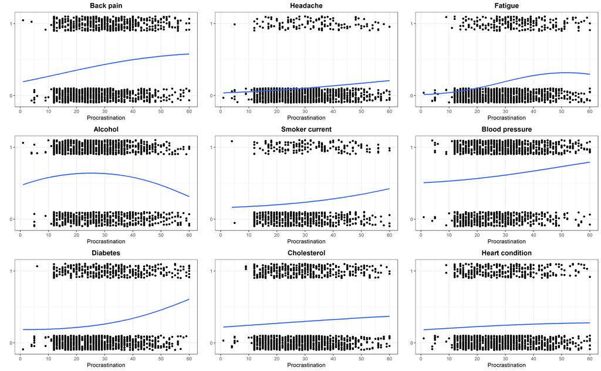

```r
knitr::include_graphics(here::here(path_graphics, "03__Curve_Plots/01__Problem_Curves.png"))
```

### Health Protection

All health protective variables have a linear association with procrastination and can be included in the standard logistic regression model.

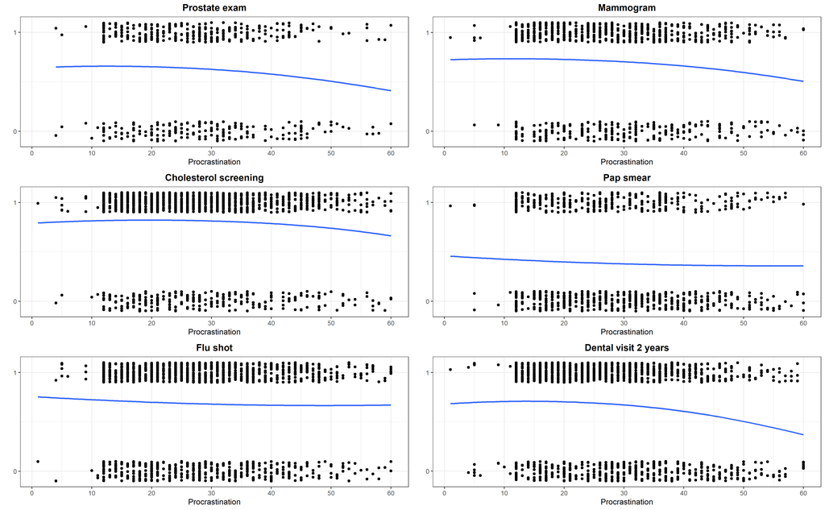

```r
knitr::include_graphics(here::here(path_graphics, "03__Curve_Plots/02__Protection_Curves.png"))
```

# Logistic Regression

Logistic regression is a statistical method used for predicting the probability of a binary outcome based on one or more predictor variables. Unlike linear regression, which predicts continuous values, logistic regression models the probability of the dependent variable belonging to a particular category.

The logistic regression equation can be written as:

$$P(Y = 1 ∣ X) = \frac{1}{1 + e^{{\beta_{0} + \beta_{1}X_{1} + \beta_{2}X_{2} + \dots + \beta_{n}X_{n}}}}$$

where $P(Y = 1 ∣ X)$ is the probability of the dependent variable ($Y$) being 1 given the values of predictors ($X$). $e$ is the base of the natural logarithm. $\beta_{0}, \beta_{1}, \beta_{2}, \dots \beta_{n}$ are the coefficients representing the effect of each predictor variable on the outcome and $X_{1}, X_{2}, \dots X_{n}$ are the values of the predictor variables.

## Performing logistic regression (no covariates)

For each variable we will apply a custom `logit_model()` function from the Functions.R script. This function applies a `glm()` model with the `family = binomial(link = "logit")` argument, whilst also storing summary output, various fit metrics generated by the [DescTools](https://andrisignorell.github.io/DescTools/) package, and the relevant odds ratio for that variable.

```r
# Defining a new vector of health problems without Alcohol
health_problems_no_alcohol <- c(
  "Back_pain", "Headache", "Fatigue", "Smoker_current",
  "Blood_pressure", "Diabetes", "Cholesterol", "Heart_condition")

# Fitting binary logistic regressions (with no covariate) ----------------------
# Fitting (health problems)
problem_models_base <- lapply(
  health_problems_no_alcohol,
  logit_model,
  predictor = "Total_procrastination",
  data = health_data,
  type = "base")

# Fitting (health protection)
protection_models_base <- lapply(
  health_protection,
  logit_model,
  predictor = "Total_procrastination",
  data = health_data,
  type = "base")
```

After fitting our base model to each variable we can better summarize and visualize our results using individual HTML tables using the [sjPlot](https://strengejacke.github.io/sjPlot/) package and an odds ratio plot using the `log_odds_plot()` function, again from the Functions.R.

```r
# Defining a vector of health problems
health_problems_tidy <- c(
  "Back Pain", "Headache", "Fatigue", "Smoking",
  "Blood Pressure", "Diabetes", "Cholesterol", "Heart Condition")

# Defining a vector of health protective behaviors
health_protection_tidy <- c(
  "Prostate Exam", "Mammogram", "Cholesterol Screening",
  "Pap Smear", "Flu Shot", "Dental Visit (2yrs)")
```

### Health Problems

**Table**

```r
sjPlot::tab_model(
  problem_models_base[[1]]$model, problem_models_base[[2]]$model,
  problem_models_base[[3]]$model, problem_models_base[[4]]$model,
  problem_models_base[[5]]$model, problem_models_base[[6]]$model,
  problem_models_base[[7]]$model, problem_models_base[[8]]$model,
  show.intercept = FALSE,
  pred.labels = "Procrastination",
  title = "Binary Logistic Regression Analysis Predicting Likelihood of Health Problems",
  dv.labels = health_problems_tidy,
  collapse.ci = TRUE, p.style = "numeric_stars"
)
```

Binary Logistic Regression Analysis Predicting Likelihood of Health Problems

|  | Back Pain |  | Headache |  | Fatigue |  | Smoking |  | Blood Pressure |  | Diabetes |  | Cholesterol |  | Heart Condition |  |
| --- | --- | --- | --- | --- | --- | --- | --- | --- | --- | --- | --- | --- | --- | --- | --- | --- |
| Predictors | Odds Ratios | p | Odds Ratios | p | Odds Ratios | p | Odds Ratios | p | Odds Ratios | p | Odds Ratios | p | Odds Ratios | p | Odds Ratios | p |
| Procrastination | 1.03 *** (1.02 – 1.04) | **<0.001** | 1.03 *** (1.02 – 1.05) | **<0.001** | 1.05 *** (1.04 – 1.06) | **<0.001** | 1.02 ** (1.01 – 1.04) | **0.002** | 1.02 *** (1.01 – 1.03) | **<0.001** | 1.04 *** (1.02 – 1.05) | **<0.001** | 1.01 * (1.00 – 1.02) | **0.015** | 1.01 (1.00 – 1.02) | 0.098 |
| Observations | 1354 |  | 1356 |  | 1356 |  | 705 |  | 1361 |  | 1361 |  | 1358 |  | 1361 |  |
| R<sup>2</sup> Tjur | 0.027 |  | 0.014 |  | 0.049 |  | 0.014 |  | 0.015 |  | 0.034 |  | 0.004 |  | 0.002 |  |
| * p<0.05 ** p<0.01 *** p<0.001 |  |  |  |  |  |  |  |  |  |  |  |  |  |  |  |  |

**Odds Plot**

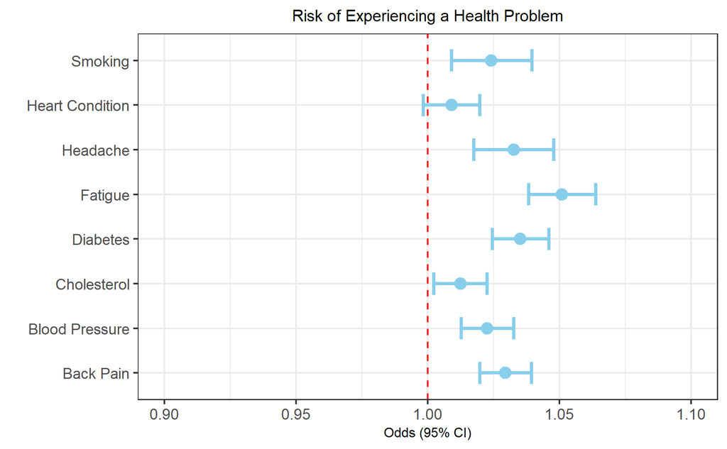

```r
knitr::include_graphics(here::here(path_graphics, "02__Odds_Plots/01__Base/01__Odds_Problem_Base.png"))
```

The results showed that procrastination was a significant predictor of all health problems except for having a heart condition, which had a non-significant positive association.

### Health Protection

**Table**

```r
sjPlot::tab_model(
  protection_models_base[[1]]$model, protection_models_base[[2]]$model,
  protection_models_base[[3]]$model, protection_models_base[[4]]$model,
  protection_models_base[[5]]$model, protection_models_base[[6]]$model,
  show.intercept = FALSE,
  pred.labels = "Procrastination",
  dv.labels = health_protection_tidy,
  title = "Binary Logistic Regression Analysis Predicting Likelihood of Health Protective Behaviours",
  collapse.ci = TRUE, p.style = "numeric_stars"
  )
```

Binary Logistic Regression Analysis Predicting Likelihood of Health Protective Behaviours

|  | Prostate Exam |  | Mammogram |  | Cholesterol Screening |  | Pap Smear |  | Flu Shot |  | Dental Visit (2yrs) |  |
| --- | --- | --- | --- | --- | --- | --- | --- | --- | --- | --- | --- | --- |
| Predictors | Odds Ratios | p | Odds Ratios | p | Odds Ratios | p | Odds Ratios | p | Odds Ratios | p | Odds Ratios | p |
| Procrastination | 0.98 * (0.97 – 1.00) | **0.045** | 0.98 ** (0.97 – 0.99) | **0.005** | 0.99 * (0.98 – 1.00) | **0.027** | 0.99 (0.98 – 1.00) | 0.262 | 0.99 (0.98 – 1.00) | 0.193 | 0.98 *** (0.97 – 0.99) | **<0.001** |
| Observations | 497 |  | 854 |  | 1346 |  | 851 |  | 1356 |  | 1359 |  |
| R<sup>2</sup> Tjur | 0.008 |  | 0.009 |  | 0.004 |  | 0.001 |  | 0.001 |  | 0.017 |  |
| * p<0.05 ** p<0.01 *** p<0.001 |  |  |  |  |  |  |  |  |  |  |  |  |

**Odds Plot**

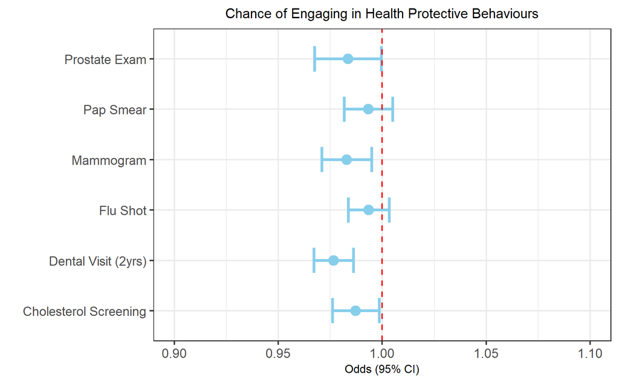

```r
knitr::include_graphics(here::here(path_graphics, "02__Odds_Plots/01__Base/02__Odds_Protection_Base.png"))
```

The results showed that procrastination was a significant negative predictor of several health protective behaviors (prostate exam, mammogram, cholesterol screening, and visiting the dentist).

## Performing logistic regression (with covariates)

This time, we will perform the same analysis but with the addition of several covariates into our model (namely Age, Education, and Depression). Again, we will be applying the `logit_model()` function to the data, but with the addition of a `type = control` argument.

```r
# Fitting binary logistic regressions (with covariate) -------------------------
problem_models_control <- lapply(
  health_problems_no_alcohol,
  logit_model,
  predictor = "Total_procrastination",
  data = health_data,
  type = "control")

protection_models_control <- lapply(
  health_protection,
  logit_model,
  predictor = "Total_procrastination",
  data = health_data,
  type = "control")
```

Again, after fitting our models we can summarize and visualize our results using HTML tables and odds plots.

### Health Problems

**Table**

```r
sjPlot::tab_model(
  problem_models_control[[1]]$model, problem_models_control[[2]]$model,
  problem_models_control[[3]]$model, problem_models_control[[4]]$model,
  problem_models_control[[5]]$model, problem_models_control[[6]]$model,
  problem_models_control[[7]]$model, problem_models_control[[8]]$model,
  show.intercept = FALSE,
  pred.labels = c("Procrastination", "Depression", "Education", "Age"),
  title = "Binary Logistic Regression Analysis Predicting Likelihood of Health Problems (with covariates)",
  dv.labels = health_problems_tidy,
  collapse.ci = TRUE, p.style = "numeric_stars"
)
```

Binary Logistic Regression Analysis Predicting Likelihood of Health Problems (with covariates)

|  | Back Pain |  | Headache |  | Fatigue |  | Smoking |  | Blood Pressure |  | Diabetes |  | Cholesterol |  | Heart Condition |  |
| --- | --- | --- | --- | --- | --- | --- | --- | --- | --- | --- | --- | --- | --- | --- | --- | --- |
| Predictors | Odds Ratios | p | Odds Ratios | p | Odds Ratios | p | Odds Ratios | p | Odds Ratios | p | Odds Ratios | p | Odds Ratios | p | Odds Ratios | p |
| Procrastination | 1.02 ** (1.01 – 1.03) | **0.003** | 1.02 (1.00 – 1.03) | 0.056 | 1.03 *** (1.02 – 1.05) | **<0.001** | 1.01 (0.99 – 1.03) | 0.252 | 1.02 ** (1.00 – 1.03) | **0.006** | 1.03 *** (1.02 – 1.04) | **<0.001** | 1.00 (0.99 – 1.02) | 0.425 | 1.00 (0.99 – 1.02) | 0.477 |
| Depression | 1.25 *** (1.18 – 1.33) | **<0.001** | 1.25 *** (1.16 – 1.35) | **<0.001** | 1.47 *** (1.38 – 1.58) | **<0.001** | 1.10 * (1.01 – 1.20) | **0.033** | 1.08 * (1.02 – 1.15) | **0.011** | 1.00 (0.94 – 1.06) | 0.933 | 1.08 * (1.01 – 1.14) | **0.015** | 1.10 ** (1.03 – 1.17) | **0.004** |
| Education | 0.96 (0.89 – 1.04) | 0.354 | 0.88 (0.77 – 1.00) | 0.052 | 1.09 (0.98 – 1.21) | 0.128 | 0.76 *** (0.66 – 0.88) | **<0.001** | 0.90 ** (0.83 – 0.97) | **0.006** | 0.86 *** (0.79 – 0.94) | **0.001** | 0.92 * (0.85 – 1.00) | **0.048** | 0.99 (0.90 – 1.08) | 0.748 |
| Age | 1.00 (0.99 – 1.01) | 0.817 | 0.97 *** (0.95 – 0.99) | **0.001** | 1.00 (0.98 – 1.01) | 0.684 | 0.93 *** (0.91 – 0.95) | **<0.001** | 1.05 *** (1.04 – 1.07) | **<0.001** | 1.01 (1.00 – 1.02) | 0.183 | 1.00 (0.99 – 1.01) | 0.723 | 1.06 *** (1.05 – 1.08) | **<0.001** |
| Observations | 1273 |  | 1275 |  | 1276 |  | 662 |  | 1280 |  | 1280 |  | 1277 |  | 1280 |  |
| R<sup>2</sup> Tjur | 0.074 |  | 0.067 |  | 0.179 |  | 0.118 |  | 0.086 |  | 0.048 |  | 0.012 |  | 0.077 |  |
| * p<0.05 ** p<0.01 *** p<0.001 |  |  |  |  |  |  |  |  |  |  |  |  |  |  |  |  |

**Odds Plot**

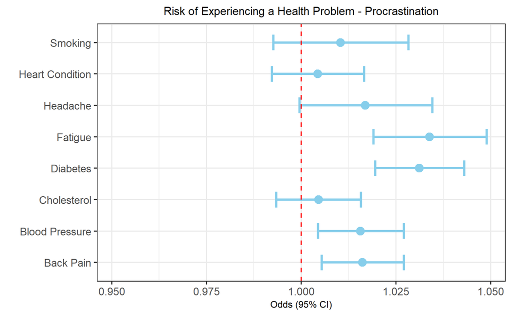

```r
knitr::include_graphics(here::here(path_graphics, "02__Odds_Plots/02__Covariates/01__Problems/01__Odds_Procrastination.png"))
```

After adding covariates to our models, the results show that procrastination was a significant predictor of experiencing fatigue, diabetes, blood pressure, and back pain.

**Odds Plot - Additional**

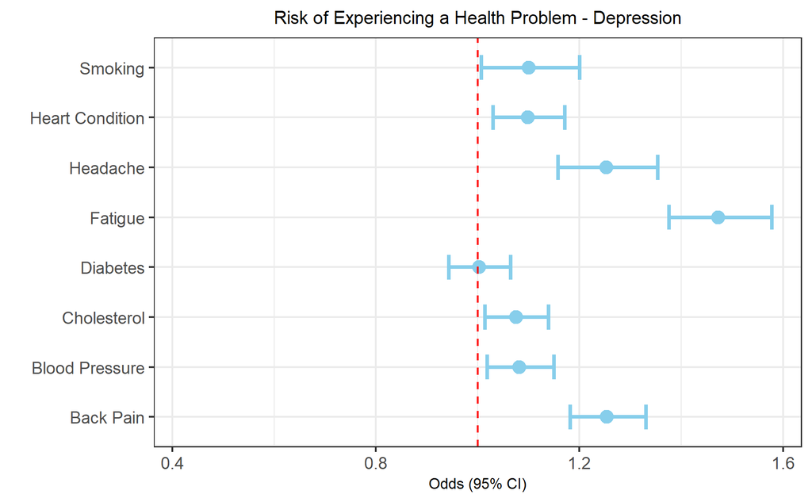

```r
knitr::include_graphics(here::here(path_graphics, "02__Odds_Plots/02__Covariates/01__Problems/02__Odds_Depression.png"))
```

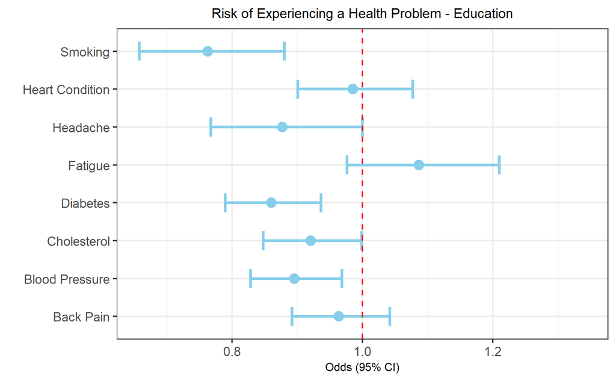

```r
knitr::include_graphics(here::here(path_graphics, "02__Odds_Plots/02__Covariates/01__Problems/03__Odds_Education.png"))
```

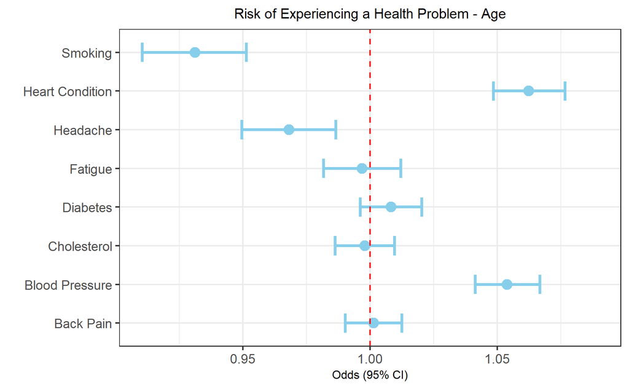

```r
knitr::include_graphics(here::here(path_graphics, "02__Odds_Plots/02__Covariates/01__Problems/04__Odds_Age.png"))
```

### Health Protection

**Table**

```r
sjPlot::tab_model(
  protection_models_control[[1]]$model, protection_models_control[[2]]$model,
  protection_models_control[[3]]$model, protection_models_control[[4]]$model,
  protection_models_control[[5]]$model, protection_models_control[[6]]$model,
  show.intercept = FALSE,
  pred.labels = c("Procrastination", "Depression", "Education", "Age"),
  title = "Binary Logistic Regression Analysis Predicting Likelihood of Health Protective Behaviours (with Covariates)",
  dv.labels = health_protection_tidy,
  collapse.ci = TRUE, p.style = "numeric_stars"
)
```

Binary Logistic Regression Analysis Predicting Likelihood of Health Protective Behaviours (with Covariates)

|  | Prostate Exam |  | Mammogram |  | Cholesterol Screening |  | Pap Smear |  | Flu Shot |  | Dental Visit (2yrs) |  |
| --- | --- | --- | --- | --- | --- | --- | --- | --- | --- | --- | --- | --- |
| Predictors | Odds Ratios | p | Odds Ratios | p | Odds Ratios | p | Odds Ratios | p | Odds Ratios | p | Odds Ratios | p |
| Procrastination | 0.99 (0.97 – 1.01) | 0.164 | 0.99 (0.98 – 1.01) | 0.246 | 1.00 (0.98 – 1.01) | 0.490 | 0.99 (0.98 – 1.01) | 0.272 | 1.00 (0.99 – 1.01) | 0.983 | 0.99 (0.98 – 1.00) | 0.076 |
| Depression | 1.05 (0.94 – 1.18) | 0.386 | 0.96 (0.90 – 1.03) | 0.265 | 0.98 (0.92 – 1.05) | 0.622 | 1.01 (0.95 – 1.09) | 0.681 | 1.01 (0.95 – 1.07) | 0.795 | 1.02 (0.96 – 1.08) | 0.546 |
| Education | 1.18 ** (1.05 – 1.34) | **0.008** | 1.16 ** (1.04 – 1.29) | **0.009** | 1.24 *** (1.13 – 1.37) | **<0.001** | 0.96 (0.86 – 1.06) | 0.410 | 1.21 *** (1.11 – 1.32) | **<0.001** | 1.57 *** (1.43 – 1.72) | **<0.001** |
| Age | 1.01 (1.00 – 1.03) | 0.139 | 0.97 *** (0.96 – 0.98) | **<0.001** | 1.03 *** (1.01 – 1.04) | **<0.001** | 0.92 *** (0.91 – 0.94) | **<0.001** | 1.06 *** (1.05 – 1.08) | **<0.001** | 0.99 (0.98 – 1.00) | 0.185 |
| Observations | 466 |  | 804 |  | 1265 |  | 801 |  | 1276 |  | 1278 |  |
| R<sup>2</sup> Tjur | 0.032 |  | 0.042 |  | 0.033 |  | 0.130 |  | 0.084 |  | 0.103 |  |
| * p<0.05 ** p<0.01 *** p<0.001 |  |  |  |  |  |  |  |  |  |  |  |  |

**Odds Plot**

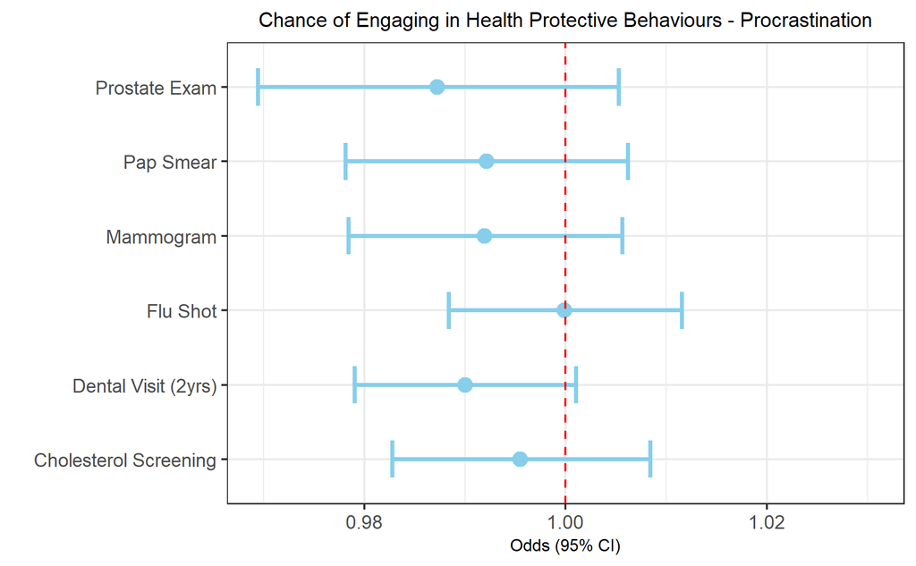

```r
knitr::include_graphics(here::here(path_graphics, "02__Odds_Plots/02__Covariates/02__Protection/01__Odds_Procrastination.png"))
```

After adding covariates to our models, the results show that procrastination was a did not predict any health protective behaviors.

**Odds Plot - Additional**

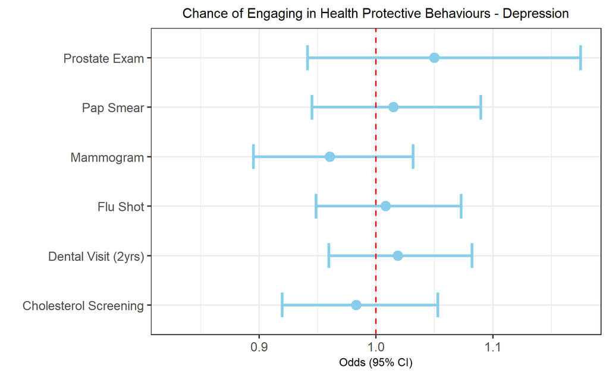

```r
knitr::include_graphics(here::here(path_graphics, "02__Odds_Plots/02__Covariates/02__Protection/02__Odds_Depression.png"))
```

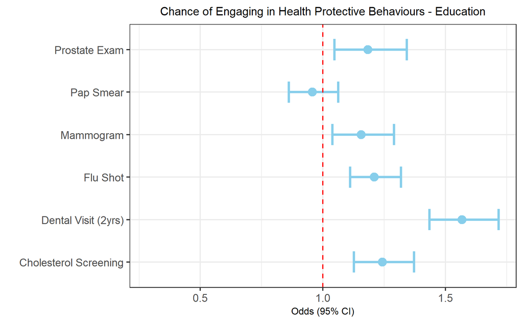

```r
knitr::include_graphics(here::here(path_graphics, "02__Odds_Plots/02__Covariates/02__Protection/03__Odds_Education.png"))
```

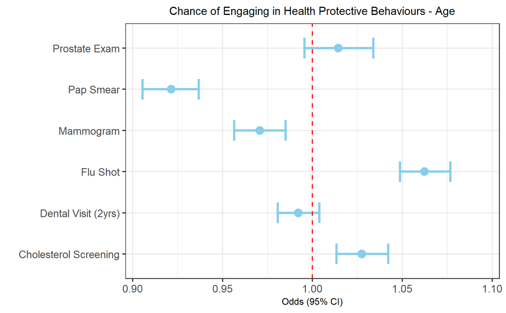

```r
knitr::include_graphics(here::here(path_graphics, "02__Odds_Plots/02__Covariates/02__Protection/04__Odds_Age.png"))
```

# Logistic Regression (Quadratic)

A quadratic term is a variable raised to the power of two, such as $x^2$. Adding a quadratic term to a logistic regression model can help capture the non-linear relationship between the outcome and the predictor, such as a U-shaped or an inverted U-shaped curve (as seen with our **Alcohol** variable).

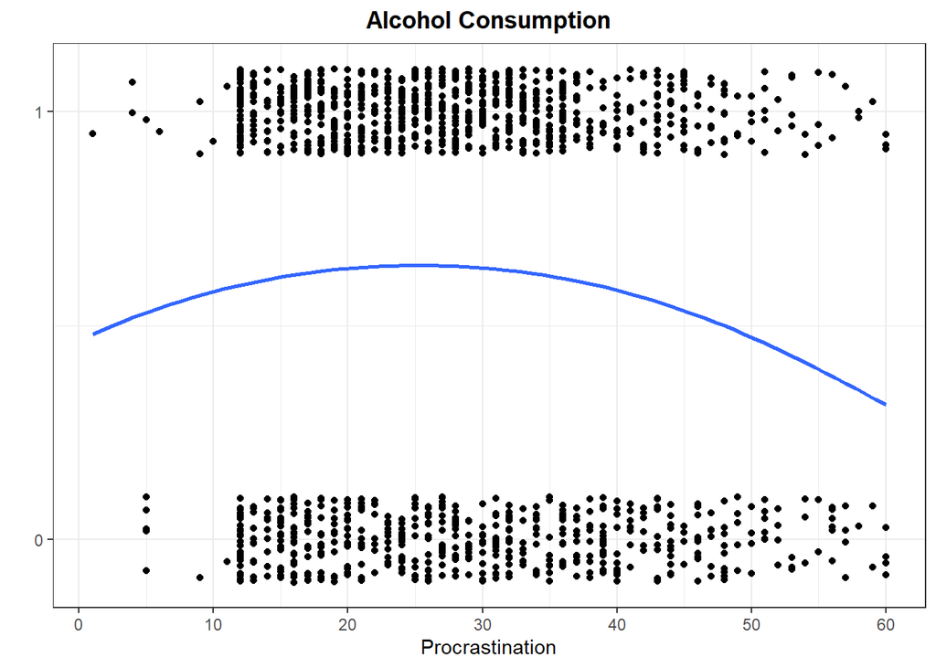

```r
  ggplot(data = health_data, aes(x = Total_procrastination, y = Alcohol)) +
    geom_jitter(width = 0, height = .1) +
    geom_smooth(formula = y ~ poly(x,2), se = FALSE, method = "glm",
                method.args = list(family = "binomial")) +
    labs(x = "Procrastination", y = "", title = "Alcohol Consumption") +
    scale_y_continuous(breaks = c(0, 1)) +
    scale_x_continuous(breaks = seq(0, 60, by = 10)) +
    theme_bw() +
    theme(plot.title = element_text(face = "bold")) +
    ggeasy::easy_center_title()
```

A logistic regression with a quadratic term can be written as:

$$logit(p) = \beta_{0} + \beta_{1}X + \beta_{2}X^2$$
where $p$ is the probability of our outcome being $1$, $\beta_{1}$ representing the linear effect of $X$ on the log odds of $p$, and $\beta_{2}$ representing the quadratic effect of $X^2$ on the log odds of $p$.

## Performing logistic regression (no covariates)

Similar to before, we will start by performing a logistic regression with no covariates. This can be done by applying a generalized linear model using the `glm()` but with an expansion to the `formula` argument to include `I(Total_procrastination^2)`, where `I(Total_procrastination^2)` represents our quadratic effect ($\beta_{2}X^2$).

```r
fit_1 <- glm(
  formula = Alcohol ~ Total_procrastination + I(Total_procrastination^2),
  data = health_data,
  family = binomial(link = "logit"))
```

After fitting this model we get the following coefficients:

$$\beta_0 = -0.1333 \quad \beta_1 = 0.0564 \quad \beta_2 = -0.0011$$
These coefficients indicate that the odds of alcohol consumption $p = 1$ depend on the level of procrastination. Specifically, the odds of alcohol consumption increase as procrastination increases up to a certain point, after which they start to decrease. This is consistent with the inverse U-shaped relationship between procrastination and alcohol consumption.

This can be better summarized and illustrated in the below table and graph

**Table**

```r
sjPlot::tab_model(
  fit_1,
  show.intercept = FALSE,
  pred.labels = c("Procrastination", "Procrastination²"),
  dv.labels = "Alcohol Consumption",
  title = "Logistic Regression Analysis Predicting Likelihood of Alcohol Consumption",
  collapse.ci = TRUE, p.style = "numeric_stars", digits = 3, digits.p = 3
  )
```

Logistic Regression Analysis Predicting Likelihood of Alcohol Consumption

|  | Alcohol Consumption |  |
| --- | --- | --- |
| Predictors | Odds Ratios | p |
| Procrastination | 1.058 * (1.013 – 1.106) | **0.012** |
| Procrastination² | 0.999 ** (0.998 – 1.000) | **0.001** |
| Observations | 1356 |  |
| R<sup>2</sup> Tjur | 0.014 |  |
| * p<0.05 ** p<0.01 *** p<0.001 |  |  |

**Figure**

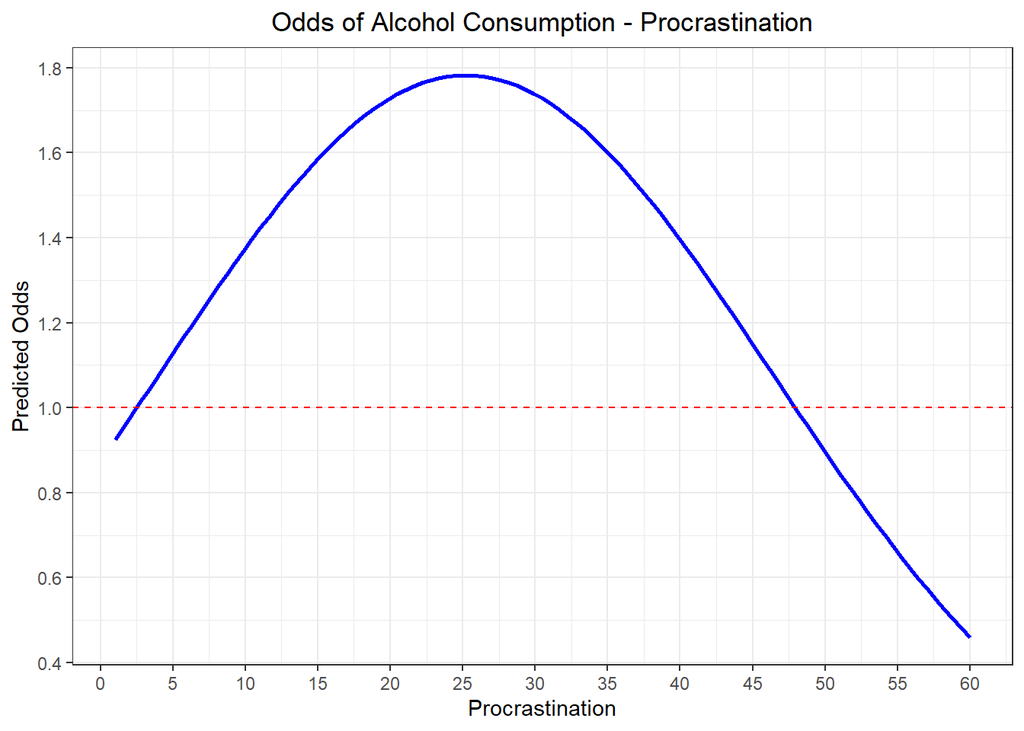

```r
# Creating a function to extract the odds ratio
odds_base <- function(x){
  exp((coef(fit_1)[3] * x^2) + (coef(fit_1)[2] * x) + coef(fit_1)[1])
}

health_data %>%
  ggplot(aes(x = Total_procrastination, y = Alcohol)) +
  stat_function(fun = odds_base, geom = "line", colour = "blue", linewidth = 1) +
  scale_x_continuous(breaks = seq(0, 60, by = 5)) +
  scale_y_continuous(breaks = seq(0.4, 1.8, by = 0.2)) +
  geom_hline(yintercept = 1, linetype = "dashed", linewidth = .5, colour = "red") +
  labs(x = "Procrastination", y = "Predicted Odds",
       title = "Odds of Alcohol Consumption - Procrastination") +
  theme_bw() +
  ggeasy::easy_center_title()
```

$$x = \frac{-\beta_1}{2(\beta_2)} = \frac{-0.0564}{2(-0.0011)} = 25.63636 \approx 26$$

This means that the vertex of the logistic function occurs when procrastination is approximately equal to 26 (exactly 25.63636)

## Performing logistic regression (with covariates)

Again, we will now add several covariates to our model (namely Age, Education, and Depression).

```r
fit_2 <- glm(
  formula = Alcohol ~ Total_procrastination + I(Total_procrastination^2) + Total_depression + Education + Age,
  data = health_data,
  family = binomial(link = "logit"))
```

Again, we can summarise and illustrate our model:

**Table**

```r
sjPlot::tab_model(
  fit_2,
  show.intercept = FALSE,
  pred.labels = c("Procrastination", "Procrastination²", "Depression", "Education", "Age"),
  dv.labels = "Alcohol Consumption",
  title = "Logistic Regression Analysis Predicting Likelihood of Alcohol Consumption (with covariates)",
  collapse.ci = TRUE, p.style = "numeric_stars", digits = 3, digits.p = 3
  )
```

Logistic Regression Analysis Predicting Likelihood of Alcohol Consumption (with covariates)

|  | Alcohol Consumption |  |
| --- | --- | --- |
| Predictors | Odds Ratios | p |
| Procrastination | 1.050 * (1.002 – 1.100) | **0.042** |
| Procrastination² | 0.999 * (0.998 – 1.000) | **0.028** |
| Depression | 0.924 ** (0.873 – 0.978) | **0.006** |
| Education | 1.253 *** (1.159 – 1.357) | **<0.001** |
| Age | 0.982 ** (0.972 – 0.993) | **0.002** |
| Observations | 1275 |  |
| R<sup>2</sup> Tjur | 0.053 |  |
| * p<0.05 ** p<0.01 *** p<0.001 |  |  |

**Figure**

This time our function calculates the predicted odds for increasing values of procrastination whilst holding the values of the covariates constant at the mean.

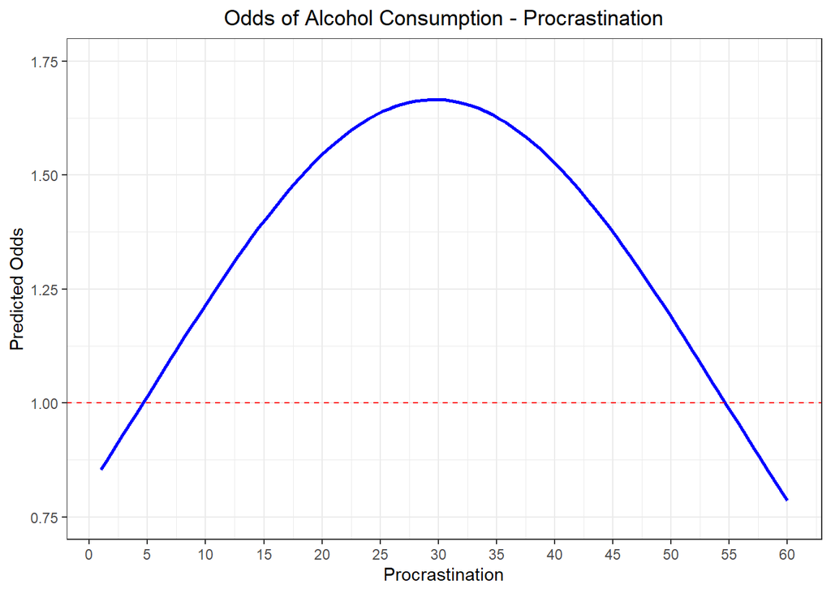

```r
odds_covariate <- function(x){
  # ax^2 + bx + c1 + c2 + ... + cn

  c1 <- coef(fit_2)[1]
  c2 <- coef(fit_2)[4] * mean(health_data$Total_depression, na.rm = TRUE)
  c3 <- coef(fit_2)[5] * mean(health_data$Education, na.rm = TRUE)
  c4 <- coef(fit_2)[6] * mean(health_data$Age, na.rm = TRUE)

  exp((coef(fit_2)[3] * x^2) + (coef(fit_2)[2] * x) + c1 + c2 + c3 + c4)
}

health_data %>%
  ggplot(aes(x = Total_procrastination, y = Alcohol)) +
  stat_function(fun = odds_covariate, geom = "line", colour = "blue", linewidth = 1) +
  scale_x_continuous(breaks = seq(0, 60, by = 5)) +
  scale_y_continuous(breaks = seq(0.75, 1.75, by = 0.25), limits = c(0.75, 1.75)) +
  geom_hline(yintercept = 1, linetype = "dashed", linewidth = .5, colour = "red") +
  labs(x = "Procrastination", y = "Predicted Odds",
       title = "Odds of Alcohol Consumption - Procrastination") +
  theme_bw() +
  ggeasy::easy_center_title()
```

Again, we can apply the vertex equation to find the turning point of this graph:

$$x = \frac{-\beta_1}{2(\beta_2)} = \frac{-0.0483}{2(-0.0008)} = 30.1875 \approx 30$$

After adding covariates to the model the vertex of this function occurs when procrastination is approximately equal to 30 (exactly 30.1875).